# Results and Discussion

GE2021 Research Technology, Fall 2026

Chad (Chungil Chae)

cchae@kean.edu

Wed, 16 September 2026

# Learning Objectives

- 13-1 Write a results section.
- 13-2 Describe how to present results in quantitative studies.
- 13-3 Explain how to present results in qualitative studies.
- 13-4 Prepare visual representations of results.
- 13-5 Compose a discussion section.
- 13-6 Develop a recommendations section based on methodology or topic.

## SHORT VIDEO INTRODUCTION

[video not shown]

# Reporting Results

- The best way to write is by starting with the section that feels most comfortable. Then, the researcher can expand, think, analyze, converse, and edit as well as add to the other sections as the work progresses.
- It is helpful to think about organization before diving in.

## Demographic Section

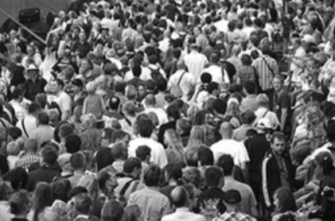

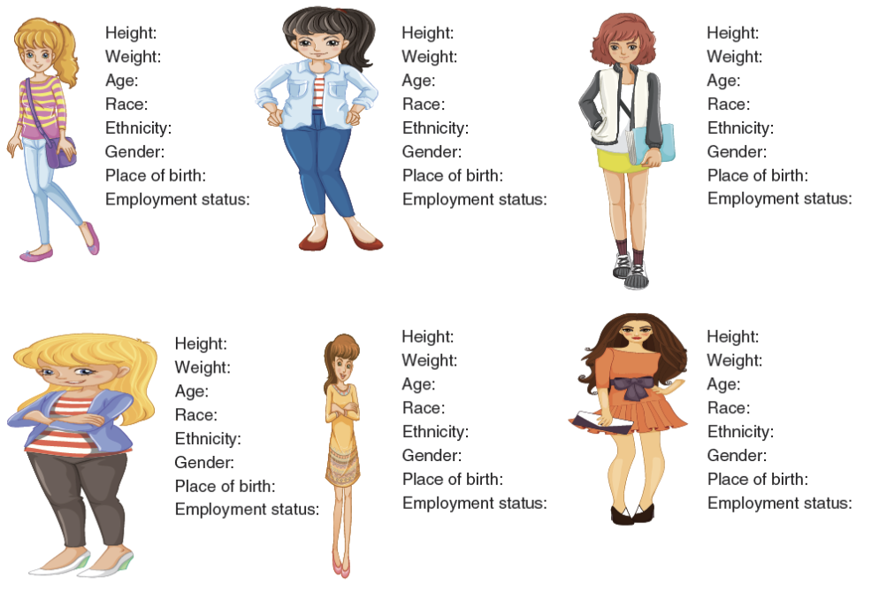

- The results section for both qualitative and quantitative designs generally begins with the demographics of the sample.
- Basic characteristics of the population, such as gender, race and ethnicity, age, height, weight, marital status, sexual orientation, religious affiliation, employment status, and income are included, as well as the number of participants in the study.
- The demographic information is important, even if the focus of research is somewhere else, seemingly unrelated to demographics.

## Findings Section

- After reporting demographics, the results section reports the findings of the study.
- In quantitative studies, researchers typically provide general information about the variables using measures such as frequency, averages, or percentages to give a broader picture of what the researcher found to be of interest.
- In qualitative studies, the results will list and discuss the codes, patterns, and themes found in the study.

# Results in Quantitative Studies

- A straightforward statement of findings is customary, written in a direct and matter-of-fact style.
- Tables and figures are strongly recommended because they allow a visual presentation of detailed data.

## Rejecting the Null Hypothesis

- Being able to reject the null hypothesis may not mean that we have proven the alternative hypothesis.
  - There are often scenarios in which we reject both the null hypothesis and the alternative hypothesis, because the relationship between variables is different than predicted.

## Failing to Reject the Null Hypothesis

- Failing to reject the null hypothesis still contributes to the advancement of science, because it means that the null hypothesis stands as an explanation for the relationship between variables of interest.
- When we fail to reject the null, we are sometimes able to identify new relationships between variables or discover other unexpected associations.

# Results in Qualitative Studies

- Results in qualitative research follow a similar format to those in quantitative studies, providing an overview of demographics and then pointing out patterns from the analysis.
- The most straightforward way to report results is to rank them in order of importance and then combine results where patterns exist.
- To support their point, researchers use quotations directly from the text, illustrate the findings with excerpts from the data, and write a complex narrative as their results.

# Visually Presenting Results

- Data visualization: visually telling story through data; a growing discipline in its own right that cuts across all other fields.
- They bring meaning, show dynamics, depict details, and ultimately illuminate the key relationships researchers and readers should be focusing on.
- The most widely used types of visual presentations are tables and figures.

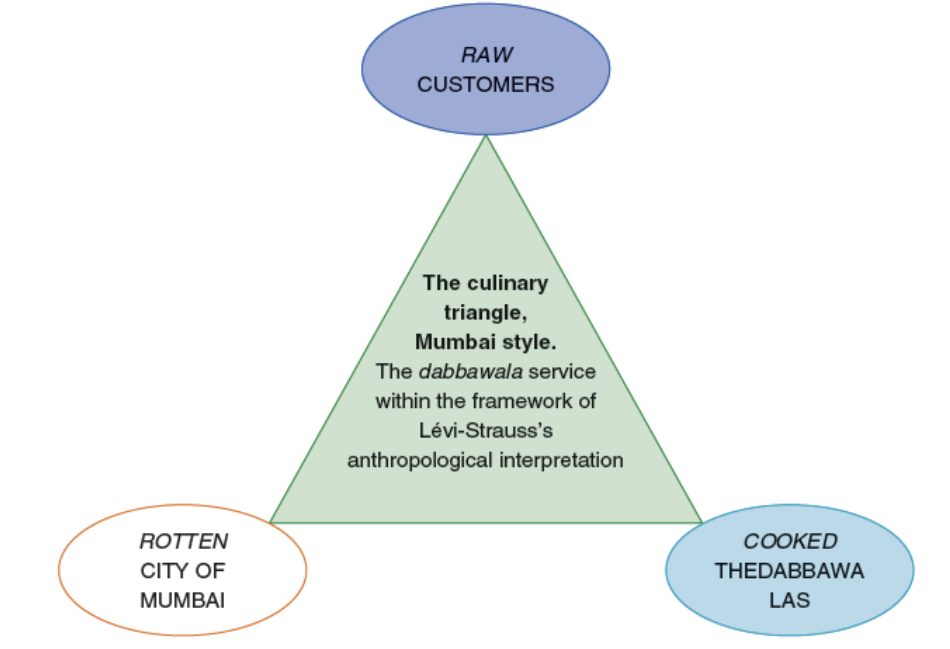

## Tables

- Tables can deliver a large amount of information at one time.
- They work best when the information is extensive and providing it in narrative form can be inefficient.
- A good rule of thumb is to present the information in a table when it occupies less space than a written rendition of the same information.
- Refrain from repeating the outcomes in a table and in the narrative; discuss the results and their implications, but do not repeat the points that have been made visually.

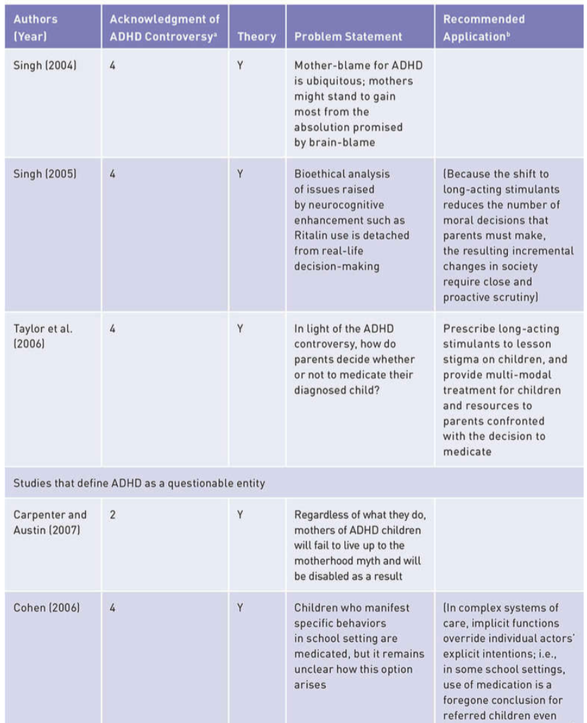